# DATA 621 Final Project

Group 2

### Overview

There are millions of stray pets around the world, some of which are fortunate enough to be adopted while many others are not. While adoption of a pet is often the definition of success, the rate at which a pet is adopted is also a key success factor - pets that take a long time to adopt contribute to over-crowded animal shelters and can prevent taking on new strays. Sadly, pets that are not adopted eventually need to be euthanized.

### Learn more about the data

[About the data](https://www.kaggle.com/c/petfinder-adoption-prediction/data)

### What to Predict

Predictor (Adoption Speed) Description: Predict how quickly, if at all, a pet is adopted.

The values are determined in the following way: 0 - Pet was adopted on the same day as it was listed. 1 - Pet was adopted between 1 and 7 days (1st week) after being listed. 2 - Pet was adopted between 8 and 30 days (1st month) after being listed. 3 - Pet was adopted between 31 and 90 days (2nd & 3rd month) after being listed. 4 - No adoption after 100 days of being listed.

### This notebook…

inputs the transformation training data and creates several models using RandomForest and XGBoost

```r
knitr::opts_chunk$set(echo = TRUE)
knitr::opts_chunk$set(message = FALSE)
knitr::opts_chunk$set(warning = FALSE)
```

```r
library(randomForest)
require(xgboost)
library(Matrix)
library(caret)
library(here)
require(caTools)

#importing our functions
source(here("R","draw_confusion_matrix.R"), local = knitr::knit_global())
```

### Load Data

Load the data

```
##   Type Breed1 Gender Color1 Color2 Color3 MaturitySize FurLength Vaccinated
## 1    1      0      2      2      0      0            2         1          1
## 2    1      0      2      2      3      0            2         1          1
##   Dewormed Sterilized Health Quantity Fee VideoAmt PhotoAmt AdoptionSpeed
## 1        1          2      1        1   0        0        3             3
## 2        1          2      1        1 100        0        5             4
##   AgeYears NumColors AllMeds
## 1        0         1       4
## 2        0         2       4
```

```r
data <- transform(
  data,
  Type=as.factor(Type),
  #Breed1=as.factor(Breed1),
  Gender=as.factor(Gender),
  Color1=as.factor(Color1),
  Color2=as.factor(Color2),
  Color3=as.factor(Color3),
  MaturitySize=as.factor(MaturitySize),
  FurLength=as.factor(FurLength),
  Vaccinated = as.factor(Vaccinated),
  Dewormed = as.factor(Dewormed),
  Sterilized = as.factor(Sterilized),
  Health = as.factor(Health),
  AdoptionSpeed = as.factor(AdoptionSpeed),
  NumColors = as.factor(NumColors)
)
```

### Functions

#### Function to create train and test

```r
source(here("R","partition_train_test_data.R"),
       local = knitr::knit_global())
```

#### Function to create RF confusion matrix

```r
create_rf_confusion_matrix <- function(pred, test){

  #Creates vectors having data points
  AdoptionSpeed_test = as.numeric(unlist(test$AdoptionSpeed))
  expected_value <- factor(c(AdoptionSpeed_test))

  predicted_value <- factor(c(pred))

  #Creating confusion matrix
  rf_confusion_matrix <- confusionMatrix(data=predicted_value, reference = expected_value, positive='1')

  #Results
  return(rf_confusion_matrix)
}
```

#### Function to create RF Model

```r
rf_model_func <- function(data) {
  #train, test data for RF model 1
  rf_train = create_train_data(data)
  rf_test = create_test_data(data)

  #create RF model 1
  rf <- randomForest(
    AdoptionSpeed ~ .,
    data=rf_train
  )

  #Predict AdoptionSpeed with RF model 1
  rf_pred = predict(rf, newdata=rf_test)

  #Create a confusion matrix for RF model 1
  rf_confusion_matrix = create_rf_confusion_matrix(rf_pred, rf_test)
  return(rf_confusion_matrix)
}
```

#### Function to create XG Boost model

```r
xg_model_func <- function(data) {
  #train, test data for XG model 1
  xg_train = as.matrix(create_train_data(data))
  xg_test = as.matrix(create_test_data(data))

  #separate out the label
  adoption_speed_train = xg_train[ , ncol(xg_train)]
  adoption_speed_test = xg_test[ , ncol(xg_test)]

  #drop AdoptionSpeed from train and test
  xg_train = subset(xg_train, select=-c(ncol(xg_train)))
  xg_test = subset(xg_test, select=-c(ncol(xg_test)))

  #XGBoost requires a dgc matrix
  xg_train=as(xg_train, "dgCMatrix")
  xg_test=as(xg_test, "dgCMatrix")

  #Create the model
  xg <- xgboost(data = xg_train, label = adoption_speed_train, nrounds = 300, verbose=0)

  #Predict
  xg_pred <- predict(xg, xg_test)

  #Create a confusion matrix for XG model 1
  xg_pred = factor(as.integer(xg_pred))
  adoption_speed_test = factor(as.integer(adoption_speed_test))

  xg_confusion_matrix = confusionMatrix(xg_pred, adoption_speed_test)
  return(xg_confusion_matrix)
}
```

### RandomForest (RF)

Helpful article from [TowardsDataScience](https://towardsdatascience.com/random-forest-in-r-f66adf80ec9)

#### RF Model #1

```r
#dataframe for RF model 1
rf_model1_data = subset(data, select = c(Type,Breed1,FurLength,Gender,Sterilized,Quantity,AgeYears,Vaccinated,AdoptionSpeed))

rf_confusion_matrix = rf_model_func(rf_model1_data)
rf_confusion_matrix
```

```
## Confusion Matrix and Statistics
##
##           Reference
## Prediction   1   2   3   4   5
##          1   5   0   1   0   0
##          2  32 240 140  88  75
##          3  45 381 633 388 336
##          4   6  30  31 100  23
##          5  14 121 204 239 615
##
## Overall Statistics
##
##                Accuracy : 0.4251
##                  95% CI : (0.4092, 0.4412)
##     No Information Rate : 0.28
##     P-Value [Acc > NIR] : < 2.2e-16
##
##                   Kappa : 0.2232
##
##  Mcnemar's Test P-Value : < 2.2e-16
##
## Statistics by Class:
##
##                      Class: 1 Class: 2 Class: 3 Class: 4 Class: 5
## Sensitivity          0.049020  0.31088   0.6274  0.12270   0.5863
## Specificity          0.999726  0.88739   0.5800  0.96930   0.7858
## Pos Pred Value       0.833333  0.41739   0.3550  0.52632   0.5155
## Neg Pred Value       0.974071  0.83228   0.8086  0.79899   0.8301
## Prevalence           0.027222  0.20603   0.2693  0.21751   0.2800
## Detection Rate       0.001334  0.06405   0.1689  0.02669   0.1641
## Detection Prevalence 0.001601  0.15346   0.4758  0.05071   0.3184
## Balanced Accuracy    0.524373  0.59914   0.6037  0.54600   0.6860
```

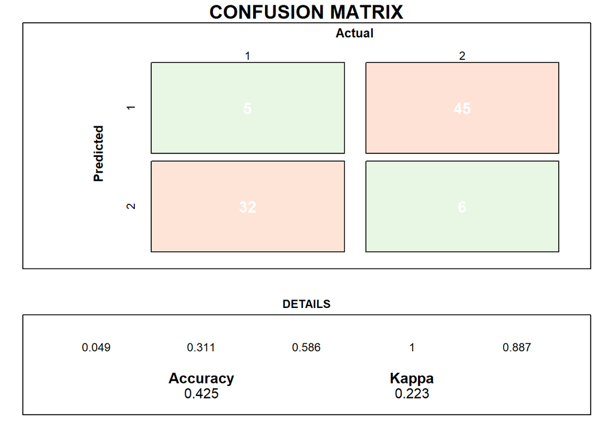

```r
draw_confusion_matrix(rf_confusion_matrix)
```

#### RF Model #2

```r
#dataframe for RF model 2
rf_model2_data = subset(data, select = c(Type,AgeYears,AdoptionSpeed))

rf_confusion_matrix = rf_model_func(rf_model2_data)
rf_confusion_matrix
```

```
## Confusion Matrix and Statistics
##
##           Reference
## Prediction   1   2   3   4   5
##          1   0   0   0   0   0
##          2   0   0   0   0   0
##          3  71 592 772 576 557
##          4   0   0   0   1   0
##          5  31 180 237 238 492
##
## Overall Statistics
##
##                Accuracy : 0.3376
##                  95% CI : (0.3225, 0.353)
##     No Information Rate : 0.28
##     P-Value [Acc > NIR] : 6.96e-15
##
##                   Kappa : 0.0893
##
##  Mcnemar's Test P-Value : NA
##
## Statistics by Class:
##
##                      Class: 1 Class: 2 Class: 3  Class: 4 Class: 5
## Sensitivity           0.00000    0.000   0.7651 0.0012270   0.4690
## Specificity           1.00000    1.000   0.3440 1.0000000   0.7457
## Pos Pred Value            NaN      NaN   0.3006 1.0000000   0.4177
## Neg Pred Value        0.97278    0.794   0.7990 0.7827015   0.7832
## Prevalence            0.02722    0.206   0.2693 0.2175073   0.2800
## Detection Rate        0.00000    0.000   0.2060 0.0002669   0.1313
## Detection Prevalence  0.00000    0.000   0.6853 0.0002669   0.3144
## Balanced Accuracy     0.50000    0.500   0.5546 0.5006135   0.6074
```

[figure not shown]

```r
draw_confusion_matrix(rf_confusion_matrix)
```

#### RF Model #3

```r
#dataframe for RF model 3
rf_model3_data = subset(data, select = c(Type,Breed1,FurLength,Gender,AgeYears,AdoptionSpeed))

rf_confusion_matrix = rf_model_func(rf_model3_data)
rf_confusion_matrix
```

```
## Confusion Matrix and Statistics
##
##           Reference
## Prediction   1   2   3   4   5
##          1   4   0   0   0   0
##          2  15 135  51  64  40
##          3  60 465 651 390 413
##          4   5  27  17  56  22
##          5  18 145 290 305 574
##
## Overall Statistics
##
##                Accuracy : 0.379
##                  95% CI : (0.3634, 0.3947)
##     No Information Rate : 0.28
##     P-Value [Acc > NIR] : < 2.2e-16
##
##                   Kappa : 0.154
##
##  Mcnemar's Test P-Value : < 2.2e-16
##
## Statistics by Class:
##
##                      Class: 1 Class: 2 Class: 3 Class: 4 Class: 5
## Sensitivity          0.039216  0.17487   0.6452  0.06871   0.5472
## Specificity          1.000000  0.94286   0.5150  0.97578   0.7191
## Pos Pred Value       1.000000  0.44262   0.3290  0.44094   0.4309
## Neg Pred Value       0.973818  0.81493   0.7975  0.79033   0.8033
## Prevalence           0.027222  0.20603   0.2693  0.21751   0.2800
## Detection Rate       0.001068  0.03603   0.1737  0.01495   0.1532
## Detection Prevalence 0.001068  0.08140   0.5282  0.03389   0.3555
## Balanced Accuracy    0.519608  0.55886   0.5801  0.52225   0.6331
```

### XGBoost (XG)

```r
#dataframe for XG model 1
xg_model1_data = subset(data, select = c(Type,Breed1,FurLength,Gender,Sterilized,Quantity,AgeYears,Vaccinated,AdoptionSpeed))

xg_confusion_matrix = xg_model_func(xg_model1_data)
xg_confusion_matrix
```

```
## Confusion Matrix and Statistics
##
##           Reference
## Prediction   0   1   2   3   4
##          0  18  16   2   3   2
##          1  28 215 124  48  27
##          2  50 500 797 598 521
##          3   6  40  84 165 454
##          4   0   1   2   1  45
##
## Overall Statistics
##
##                Accuracy : 0.3309
##                  95% CI : (0.3159, 0.3463)
##     No Information Rate : 0.28
##     P-Value [Acc > NIR] : 4.615e-12
##
##                   Kappa : 0.1091
##
##  Mcnemar's Test P-Value : < 2.2e-16
##
## Statistics by Class:
##
##                      Class: 0 Class: 1 Class: 2 Class: 3 Class: 4
## Sensitivity          0.176471  0.27850   0.7899  0.20245  0.04290
## Specificity          0.993690  0.92370   0.3904  0.80082  0.99852
## Pos Pred Value       0.439024  0.48643   0.3232  0.22029  0.91837
## Neg Pred Value       0.977334  0.83147   0.8345  0.78319  0.72850
## Prevalence           0.027222  0.20603   0.2693  0.21751  0.27996
## Detection Rate       0.004804  0.05738   0.2127  0.04404  0.01201
## Detection Prevalence 0.010942  0.11796   0.6581  0.19989  0.01308
## Balanced Accuracy    0.585080  0.60110   0.5902  0.50164  0.52071
```

#### XG Model #2

```r
#dataframe for XG model 2
xg_model2_data = subset(data, select = c(Type,AgeYears,AdoptionSpeed))

xg_confusion_matrix = xg_model_func(xg_model2_data)
xg_confusion_matrix
```

```
## Confusion Matrix and Statistics
##
##           Reference
## Prediction    0    1    2    3    4
##          0    0    0    0    0    0
##          1    0    1    0    0    0
##          2  102  764 1002  808 1027
##          3    0    7    7    7   22
##          4    0    0    0    0    0
##
## Overall Statistics
##
##                Accuracy : 0.2695
##                  95% CI : (0.2554, 0.2841)
##     No Information Rate : 0.28
##     P-Value [Acc > NIR] : 0.9251
##
##                   Kappa : 0.0012
##
##  Mcnemar's Test P-Value : NA
##
## Statistics by Class:
##
##                      Class: 0  Class: 1 Class: 2 Class: 3 Class: 4
## Sensitivity           0.00000 0.0012953  0.99306 0.008589     0.00
## Specificity           1.00000 1.0000000  0.01351 0.987722     1.00
## Pos Pred Value            NaN 1.0000000  0.27059 0.162791      NaN
## Neg Pred Value        0.97278 0.7941805  0.84091 0.781857     0.72
## Prevalence            0.02722 0.2060315  0.26928 0.217507     0.28
## Detection Rate        0.00000 0.0002669  0.26741 0.001868     0.00
## Detection Prevalence  0.00000 0.0002669  0.98826 0.011476     0.00
## Balanced Accuracy     0.50000 0.5006477  0.50329 0.498155     0.50
```

```r
#dataframe for XG model 3
xg_model3_data = subset(data, select = c(Type,Breed1,FurLength,Gender,AgeYears,AdoptionSpeed))

#xg_confusion_matrix = xg_model_func(xg_model3_data)
#xg_confusion_matrix
```